# Google Capstone Study: Bellabeat.

Henry Osamwonyi Irabor

2022-05-22

## Data Analysis Process

Bellabeat is a global digital organization that focuses on women’s fitness. Their products mostly comprise of fitness monitoring technologies that track sleep, calories, heartbeat, weight-loss, distance travelled etc.

The Bellabeat wants to know how custpmers use its product. So they want me to look at external data identify customer trends in the industry.

### Ask

1. What is the problem you are trying to solve?
   - Ans: I am trying to determine how customers use Bellabeat’s products.
2. How can your insights drive business decisions?
   - Ans: My insights can influence marketing strategies, as they will inform the company of trends in product usage.

**Business Task:** Analyze trends in the Fitbit data to understand how customers use fitness trackers.

### Prepare

The data does not completely pass the **ROCCC** test because

- The small sample size makes it unreliable.
- The data source Fitbit is known, so it is original
- The datasets are comprehensive.
- The data was collected in 2016, therefore it is not current
- The data has no citation

We then load the required R packages

```r
library(tidyverse)
library(lubridate)
library(gsubfn)
library(ggExtra)
```

Next we import the required csv files into R:

```r
sleep_day <- read.csv("sleepDay_merged.csv")
daily_activity <- read.csv("dailyActivity_merged.csv")
daily_calories <- read.csv("dailyCalories_merged.csv")
weight <- read.csv("WeightLogInfo_merged.csv")
```

View the data structure

```r
View(sleep_day)
str(sleep_day)
```

```
## 'data.frame':    413 obs. of  5 variables:
##  $ Id                : num  1.5e+09 1.5e+09 1.5e+09 1.5e+09 1.5e+09 ...
##  $ SleepDay          : chr  "4/12/2016 12:00:00 AM" "4/13/2016 12:00:00 AM" "4/15/2016 12:00:00 AM" "4/16/2016 12:00:00 AM" ...
##  $ TotalSleepRecords : int  1 2 1 2 1 1 1 1 1 1 ...
##  $ TotalMinutesAsleep: int  327 384 412 340 700 304 360 325 361 430 ...
##  $ TotalTimeInBed    : int  346 407 442 367 712 320 377 364 384 449 ...
```

```r
View(daily_activity)
str(daily_activity)
```

```
## 'data.frame':    940 obs. of  15 variables:
##  $ Id                      : num  1.5e+09 1.5e+09 1.5e+09 1.5e+09 1.5e+09 ...
##  $ ActivityDate            : chr  "4/12/2016" "4/13/2016" "4/14/2016" "4/15/2016" ...
##  $ TotalSteps              : int  13162 10735 10460 9762 12669 9705 13019 15506 10544 9819 ...
##  $ TotalDistance           : num  8.5 6.97 6.74 6.28 8.16 ...
##  $ TrackerDistance         : num  8.5 6.97 6.74 6.28 8.16 ...
##  $ LoggedActivitiesDistance: num  0 0 0 0 0 0 0 0 0 0 ...
##  $ VeryActiveDistance      : num  1.88 1.57 2.44 2.14 2.71 ...
##  $ ModeratelyActiveDistance: num  0.55 0.69 0.4 1.26 0.41 ...
##  $ LightActiveDistance     : num  6.06 4.71 3.91 2.83 5.04 ...
##  $ SedentaryActiveDistance : num  0 0 0 0 0 0 0 0 0 0 ...
##  $ VeryActiveMinutes       : int  25 21 30 29 36 38 42 50 28 19 ...
##  $ FairlyActiveMinutes     : int  13 19 11 34 10 20 16 31 12 8 ...
##  $ LightlyActiveMinutes    : int  328 217 181 209 221 164 233 264 205 211 ...
##  $ SedentaryMinutes        : int  728 776 1218 726 773 539 1149 775 818 838 ...
##  $ Calories                : int  1985 1797 1776 1745 1863 1728 1921 2035 1786 1775 ...
```

```r
view(daily_calories)
str(daily_calories)
```

```
## 'data.frame':    940 obs. of  3 variables:
##  $ Id         : num  1.5e+09 1.5e+09 1.5e+09 1.5e+09 1.5e+09 ...
##  $ ActivityDay: chr  "4/12/2016" "4/13/2016" "4/14/2016" "4/15/2016" ...
##  $ Calories   : int  1985 1797 1776 1745 1863 1728 1921 2035 1786 1775 ...
```

```r
view(weight)
str(weight)
```

```
## 'data.frame':    67 obs. of  8 variables:
##  $ Id            : num  1.50e+09 1.50e+09 1.93e+09 2.87e+09 2.87e+09 ...
##  $ Date          : chr  "5/2/2016 11:59:59 PM" "5/3/2016 11:59:59 PM" "4/13/2016 1:08:52 AM" "4/21/2016 11:59:59 PM" ...
##  $ WeightKg      : num  52.6 52.6 133.5 56.7 57.3 ...
##  $ WeightPounds  : num  116 116 294 125 126 ...
##  $ Fat           : int  22 NA NA NA NA 25 NA NA NA NA ...
##  $ BMI           : num  22.6 22.6 47.5 21.5 21.7 ...
##  $ IsManualReport: chr  "True" "True" "False" "True" ...
##  $ LogId         : num  1.46e+12 1.46e+12 1.46e+12 1.46e+12 1.46e+12 ...
```

## Process

Clean data by removing any duplicates or rows with missing data

```r
sleep_day_clean <- sleep_day[!duplicated(sleep_day), ] %>%
  na.omit()

daily_activity_clean <- daily_activity[!duplicated(daily_activity), ] %>%
  na.omit()

daily_calories_clean <- daily_calories[!duplicated(daily_calories), ] %>%
  na.omit()

weight_clean <- weight[!duplicated(weight), ]
```

The weight dataset has a particular variable with lots of N/A fields, therefore removing rows with missing data, will make the dataset too small.

After data cleaning, we need to know how many unique customers we have in each data set

```r
daily_activity_clean %>%
  count(Id)
```

```
##            Id  n
## 1  1503960366 31
## 2  1624580081 31
## 3  1644430081 30
## 4  1844505072 31
## 5  1927972279 31
## 6  2022484408 31
## 7  2026352035 31
## 8  2320127002 31
## 9  2347167796 18
## 10 2873212765 31
## 11 3372868164 20
## 12 3977333714 30
## 13 4020332650 31
## 14 4057192912  4
```

[output cut: 19 more lines]

The daily activity dataset gives us 33 unique customers

```r
sleep_day_clean %>%
  count(Id)
```

```
##            Id  n
## 1  1503960366 25
## 2  1644430081  4
## 3  1844505072  3
## 4  1927972279  5
## 5  2026352035 28
## 6  2320127002  1
## 7  2347167796 15
## 8  3977333714 28
## 9  4020332650  8
## 10 4319703577 26
## 11 4388161847 23
## 12 4445114986 28
## 13 4558609924  5
## 14 4702921684 27
## 15 5553957443 31
## 16 5577150313 26
## 17 6117666160 18
## 18 6775888955  3
## 19 6962181067 31
## 20 7007744171  2
## 21 7086361926 24
## 22 8053475328  3
## 23 8378563200 31
## 24 8792009665 15
```

The sleep dataset gives us 24 unique customers

```r
daily_calories_clean %>% count(Id)
```

```
##            Id  n
## 1  1503960366 31
## 2  1624580081 31
## 3  1644430081 30
## 4  1844505072 31
## 5  1927972279 31
## 6  2022484408 31
## 7  2026352035 31
## 8  2320127002 31
## 9  2347167796 18
## 10 2873212765 31
## 11 3372868164 20
## 12 3977333714 30
## 13 4020332650 31
## 14 4057192912  4
```

[output cut: 19 more lines]

The daily calories dataset also gives us 33 customers

```r
weight_clean %>% count(Id)
```

```
##           Id  n
## 1 1503960366  2
## 2 1927972279  1
## 3 2873212765  2
## 4 4319703577  2
## 5 4558609924  5
## 6 5577150313  1
## 7 6962181067 30
## 8 8877689391 24
```

The weight dataset contains only 8 unique customers

The sleepday column under the sleep dataset contains string variables not dates, not dates, therefore we must remove certain unwanted parts of the string

```r
sleep_day_clean$SleepDay <- gsub(
  " 12:00:00 AM", "",
  as.character(sleep_day_clean$SleepDay)
)
```

Before analysis, we shall create another variable called weekday witin the daily activity, daily calories and sleep datasets.

```r
daily_activity_clean <- daily_activity_clean %>%
  mutate(Weekday = weekdays
  (as.Date(ActivityDate, "%m/%d/%Y")))
glimpse(daily_activity_clean)
```

```
## Rows: 940
## Columns: 16
## $ Id                       <dbl> 1503960366, 1503960366, 1503960366, 150396036~
## $ ActivityDate             <chr> "4/12/2016", "4/13/2016", "4/14/2016", "4/15/~
## $ TotalSteps               <int> 13162, 10735, 10460, 9762, 12669, 9705, 13019~
## $ TotalDistance            <dbl> 8.50, 6.97, 6.74, 6.28, 8.16, 6.48, 8.59, 9.8~
## $ TrackerDistance          <dbl> 8.50, 6.97, 6.74, 6.28, 8.16, 6.48, 8.59, 9.8~
## $ LoggedActivitiesDistance <dbl> 0, 0, 0, 0, 0, 0, 0, 0, 0, 0, 0, 0, 0, 0, 0, ~
## $ VeryActiveDistance       <dbl> 1.88, 1.57, 2.44, 2.14, 2.71, 3.19, 3.25, 3.5~
## $ ModeratelyActiveDistance <dbl> 0.55, 0.69, 0.40, 1.26, 0.41, 0.78, 0.64, 1.3~
## $ LightActiveDistance      <dbl> 6.06, 4.71, 3.91, 2.83, 5.04, 2.51, 4.71, 5.0~
## $ SedentaryActiveDistance  <dbl> 0, 0, 0, 0, 0, 0, 0, 0, 0, 0, 0, 0, 0, 0, 0, ~
## $ VeryActiveMinutes        <int> 25, 21, 30, 29, 36, 38, 42, 50, 28, 19, 66, 4~
## $ FairlyActiveMinutes      <int> 13, 19, 11, 34, 10, 20, 16, 31, 12, 8, 27, 21~
## $ LightlyActiveMinutes     <int> 328, 217, 181, 209, 221, 164, 233, 264, 205, ~
## $ SedentaryMinutes         <int> 728, 776, 1218, 726, 773, 539, 1149, 775, 818~
## $ Calories                 <int> 1985, 1797, 1776, 1745, 1863, 1728, 1921, 203~
## $ Weekday                  <chr> "Tuesday", "Wednesday", "Thursday", "Friday",~
```

```r
sleep_day_clean <- sleep_day_clean %>%
  mutate(Weekday = weekdays
  (as.Date(SleepDay, "%m/%d/%Y")))
glimpse(sleep_day_clean)
```

```
## Rows: 410
## Columns: 6
## $ Id                 <dbl> 1503960366, 1503960366, 1503960366, 1503960366, 150~
## $ SleepDay           <chr> "4/12/2016", "4/13/2016", "4/15/2016", "4/16/2016",~
## $ TotalSleepRecords  <int> 1, 2, 1, 2, 1, 1, 1, 1, 1, 1, 1, 1, 1, 1, 1, 1, 1, ~
## $ TotalMinutesAsleep <int> 327, 384, 412, 340, 700, 304, 360, 325, 361, 430, 2~
## $ TotalTimeInBed     <int> 346, 407, 442, 367, 712, 320, 377, 364, 384, 449, 3~
## $ Weekday            <chr> "Tuesday", "Wednesday", "Friday", "Saturday", "Sund~
```

```r
daily_calories_clean <- daily_calories_clean %>%
  mutate(Weekday = weekdays
  (as.Date(ActivityDay, "%m/%d/%Y")))
glimpse(daily_calories_clean)
```

```
## Rows: 940
## Columns: 4
## $ Id          <dbl> 1503960366, 1503960366, 1503960366, 1503960366, 1503960366~
## $ ActivityDay <chr> "4/12/2016", "4/13/2016", "4/14/2016", "4/15/2016", "4/16/~
## $ Calories    <int> 1985, 1797, 1776, 1745, 1863, 1728, 1921, 2035, 1786, 1775~
## $ Weekday     <chr> "Tuesday", "Wednesday", "Thursday", "Friday", "Saturday", ~
```

Under the sleep dataset, we shall also create columns for hourly measurements

```r
updated_sleep_day <- sleep_day_clean %>%
  mutate(
    Total_hours_asleep = TotalMinutesAsleep / 60,
    Total_hours_in_bed = TotalTimeInBed / 60
  )

updated_sleep_day$Total_hours_in_bed <-
  round(updated_sleep_day$Total_hours_in_bed, digits = 2)

updated_sleep_day$Total_hours_asleep <-
  round(updated_sleep_day$Total_hours_asleep, digits = 2)
```

### Analysis/Visualization

From the daily activity dataset, we shall then plot calories against total number of steps

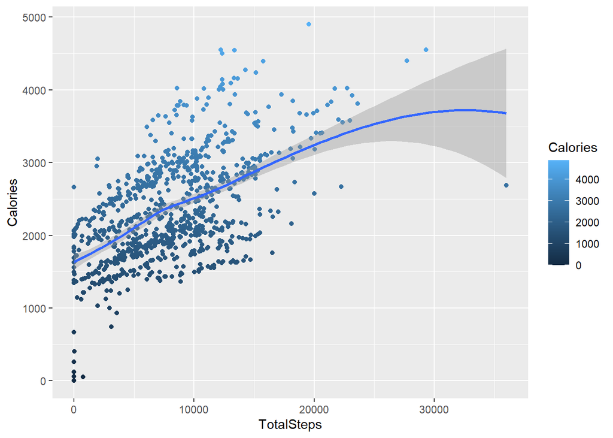

```r
ggplot(
  data = daily_activity_clean,
  mapping = aes(x = TotalSteps, y = Calories)
) +
  geom_point(aes(color = Calories)) +
  geom_smooth()
```

From the scatterplot above, it is inferred that calories burned has a positive correlation with the total number of steps taken by users.

We will then use the sleep dataset, and plot the total hours asleep against weekday, to understand how sleep is distributed along weekdays for customers that sleep either once, twice or thrice per day.

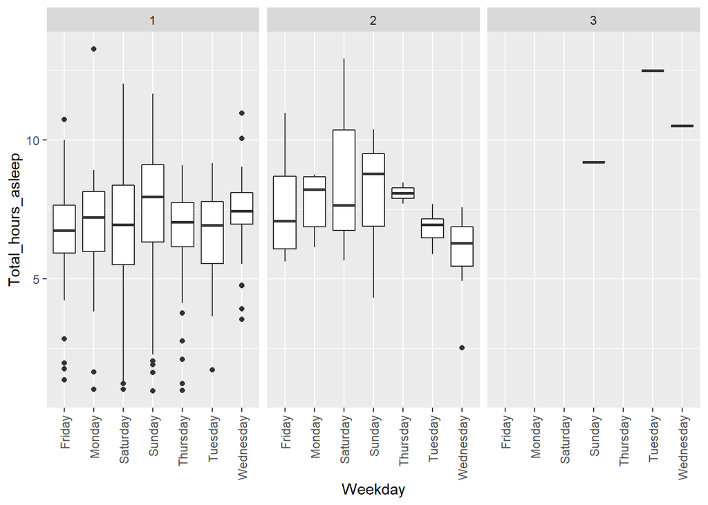

```r
ggplot(
  data = updated_sleep_day,
  mapping = aes(
    x = Weekday,
    y = Total_hours_asleep
  )
) +
  geom_boxplot() +
  facet_wrap(~TotalSleepRecords) +
  ggExtra::rotateTextX()
```

From the box-plot above it is inferred that **Sundays** have the highest mean for total number of hours slept

From the daily calorie dataset, we will plot calorie against weekday to observe which days customers burn calories the most.

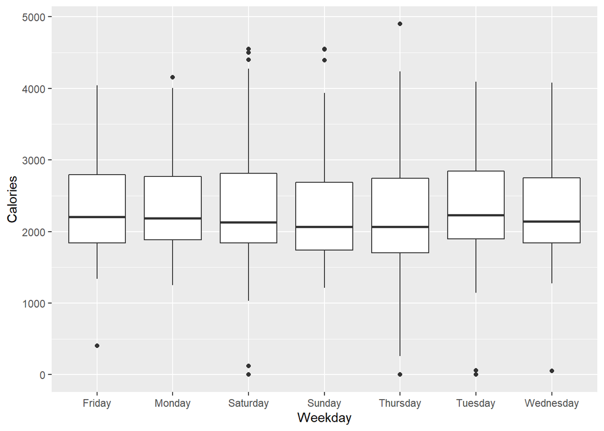

```r
daily_calories_clean %>%
  ggplot(aes(Weekday, Calories, color = Calories)) +
  geom_boxplot()
```

From the box-plot above, there is not any particular trend between calories burned and weekday

Gor a more effective analysis, let us combine activity day and sleep data sets. But to do this, we must make all the column names of primary and foreign keys match by renaming them.

```r
Sleep_data <- updated_sleep_day %>%
  rename(Date = SleepDay)

Daily_activity_data <- daily_activity_clean %>%
  rename(Date = ActivityDate)
```

Merge datasets using the Date and ID column

```r
merged_data <- merge(Daily_activity_data, Sleep_data, by = c("Id", "Date"))
```

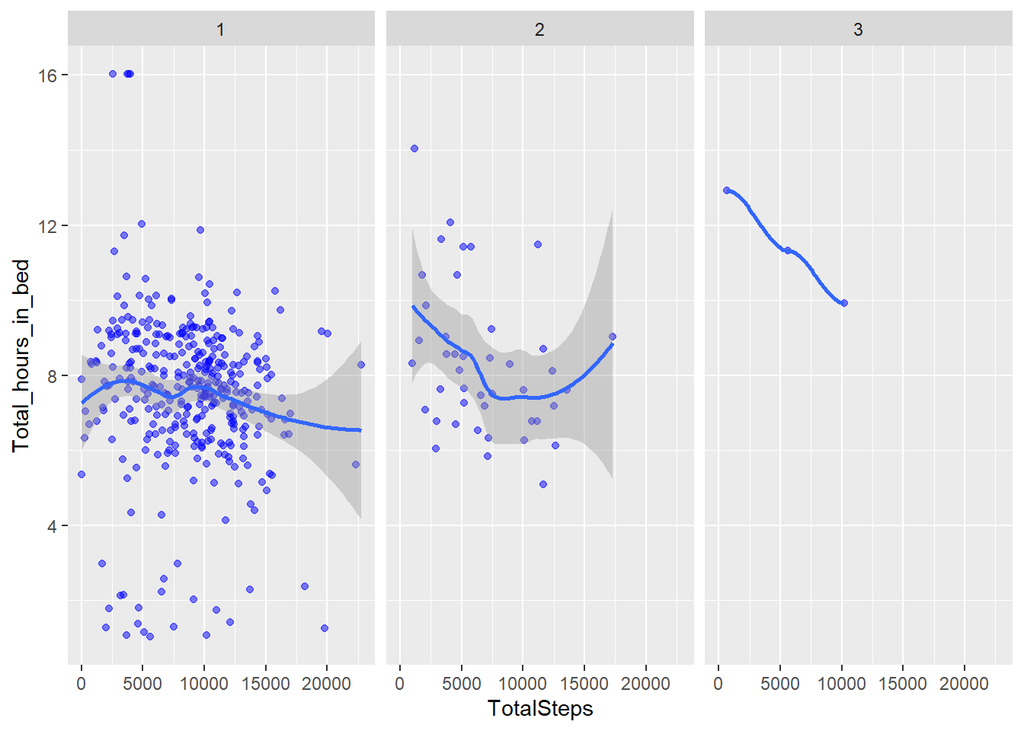

```r
merged_data %>%
  ggplot(aes(TotalSteps, Total_hours_in_bed)) +
  geom_point(color = "Blue", alpha = 0.5) +
  geom_smooth() +
  facet_wrap(~TotalSleepRecords)
```

From the charts above, there is no identifiable relationship between sleep and steps taken.

```r
weight_clean$Date1 = str_sub(weight_clean$Date,1,8)

merged_data_conv <- merged_data %>%
  rename(Date1 = Date)
```

Merge datasets

```r
merged_data2 <- merge(merged_data_conv, weight_clean, by = c("Id", "Date1"))
```

Next we plot a graph to determine any realationship between total number of steps taken, and weight in pounds.

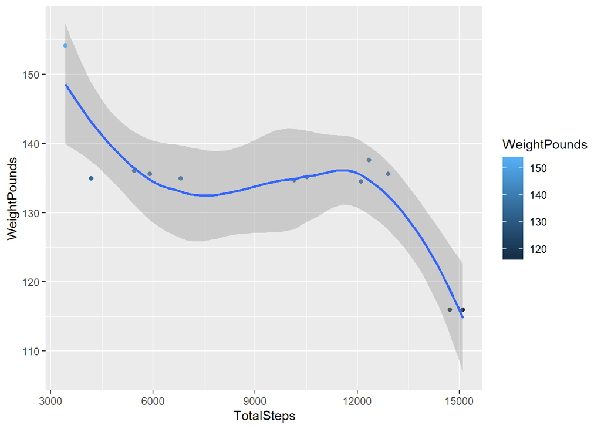

```r
merged_data2 %>%
  ggplot(aes(TotalSteps, WeightPounds))+
  geom_point(aes(color = WeightPounds))+
  geom_smooth()
```

Calories against weight

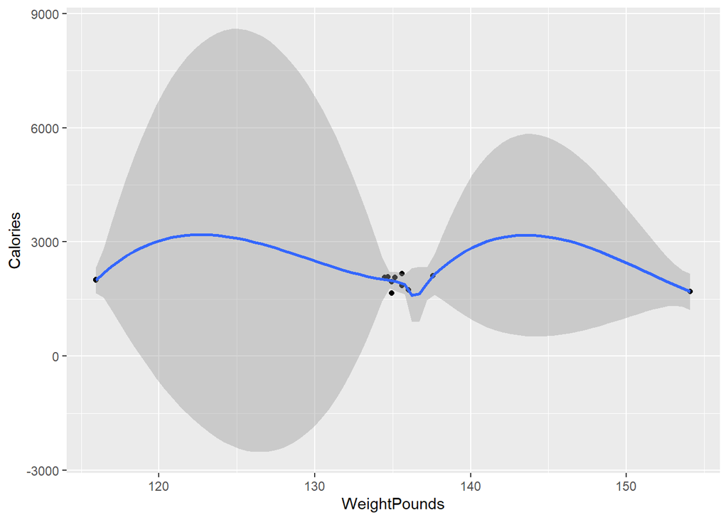

```r
merged_data2 %>%
  ggplot(aes(WeightPounds, Calories))+
  geom_point()+
  geom_smooth()
```